# Trabalho Final

Anna Monteiro

2025-06-20

# Peixe-papagaio brasileiro (Sparisoma amplum)

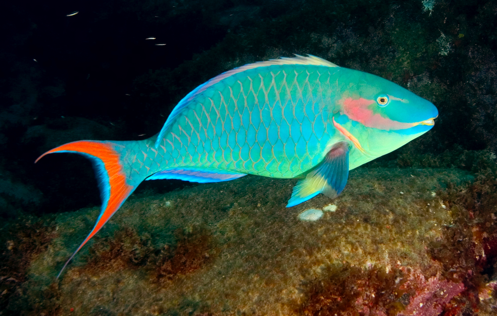

Os peixes papagaio são espécies chave em ecossistemas recifais rasos, uma vez que os mesmos possuem uma adaptação única do aparato bocal em formato de “bico”, a qual proporciona mordidas em substratos duros. Tais organismos se alimentam majoritariamente de microalgas endolíticas que residem dentro de organismos holobiontes coralíneos (corais duros), ocupando um nicho ecológico único e por sua vez proporcionando uma importante ciclagem de carbono inorgânico do carbonato de cálcio (CaCO3) adquirido através dos esqueletos de corais duros.

A espécie de peixe-papagaio Sparisoma amplum possui cores exuberantes desde a sua fase inicial a até sua fase terminal, sendo majoritariamente vermelho no início e depois alterando sua cor mesclando diferentes tons de azul e verde com detalhes em vermelho.

Os peixes papagaios apresentam hermafroditismo sequencial em seu ciclo de vida, que acompanha a mudança de cor dos mesmos: Quando está em sua fase inicial, o indivíduo possui sexo feminino e é vermelho, enquanto na fase terminal o indivíduo se torna macho e apresenta cor majoritária azul com detalhes em vermelho na nadadeira caudal e na cabeça.

Por ser endêmico do Brasil, ocorrências de S. amplum são catalogadas desde o norte de São Paulo na costa brasileira, até o final da região Nordeste. Além disso, as ilhas oceânicas do brasileiras também apresentam S. amplum em sua assembléia de peixes, sendo estas Arquipélago Fernando de Noronha; Ilha de Trindade e Martim-vaz; Arquipélago de São Pedro e São Paulo e Atol das Rocas.

# Ocorrências por regiões:

Mapa interativo de regiões em que S. amplum foi registrado:

[interactive chart not shown]

# Ocorrências por localidade:

Note que as localidades fazem parte das regiões marcadas no mapa acima em escala maior, provenientes de ambientes recifais da costa brasileira e das ilhas oceânicas brasileiras, pois S. amplum é uma espécie endêmica do Brasil.

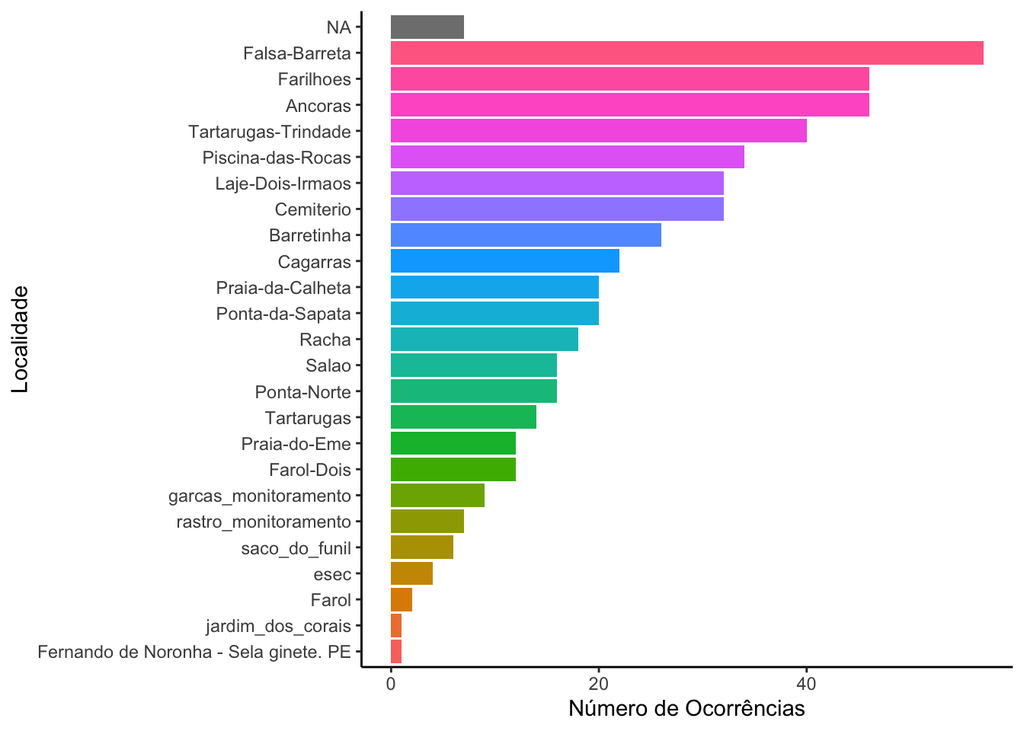

# Ocorrências por profundidade:

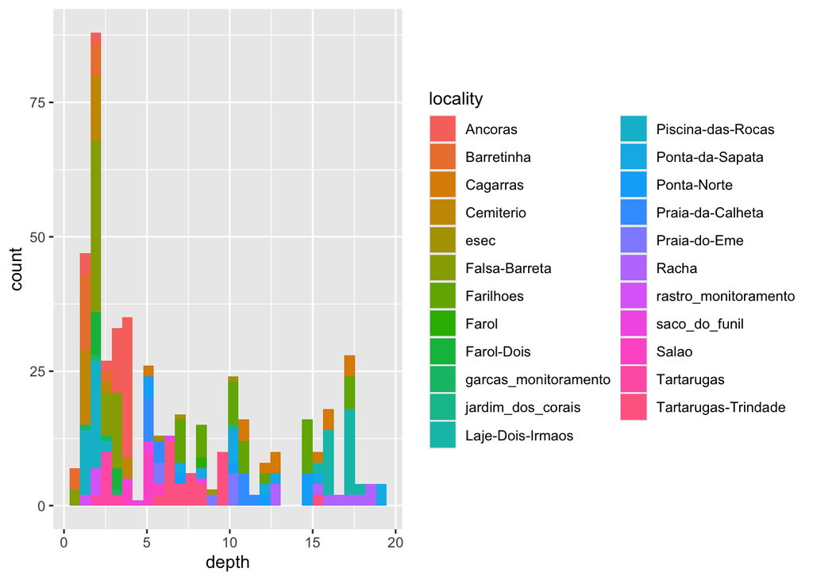